# Twitter Sentiment Analysis

```python
import tweepy
from tweepy import OAuthHandler

import csv
import operator
import pandas as pd
import numpy as np
import re
from nltk.stem.porter import *

from sklearn.linear_model import LogisticRegression
from sklearn.naive_bayes import GaussianNB
from sklearn.svm import LinearSVC
from sklearn.metrics import accuracy_score
from sklearn.model_selection import train_test_split
from sklearn.feature_extraction.text import TfidfVectorizer, CountVectorizer

import matplotlib.pyplot as plt
from wordcloud import WordCloud
```

Part 1: Tweet Scraping

To be able to download tweets using Python, we have to set up a twitter API using the following steps:

1. Log in or make a Twitter account at https://apps.twitter.com/
2. Create a new app (top right button)
3. Fill in application creation page
4. Once project has been created, click on 'Keys and Access Tokens'. You should see your consumer secret and consumer key. Copy these.
5. Scroll down and request the access tokens. You should now have an access token and access token secret. Copy these.

```python
# adding our authentication information
consumer_key = ('MPFfLrH0oE4tsMUPqwxm3bYga')
consumer_secret = ('ih0aqvAJAGe1XoCaYCLPFjGLFTYAlU1HMqoCYGve2YW8IYmych')
access_token = ('2847380567-OHy8Q8P2M9bq0uMkvNycaJqaiicaPkbEaLE2ST7')
access_secret = ('5oIYDkBfDWnEyntge25gQQaOlGyVhYqDcMebDX61UYtvY')
```

```python
# creating our API object
auth = OAuthHandler(consumer_key, consumer_secret)
auth.set_access_token(access_token, access_secret)
api = tweepy.API(auth)
```

There are different ways to retrieve tweets in Python. We are using the 'tweepy' package to scrape tweets in two different ways:

1. We are going to retrieve tweets from a specific user, 'Donald Trump'
2. We are going to retrieve tweets from a specific keyword, 'Trump'

```python
# getting tweets from a specific user
name = 'realDonaldTrump'
tweet_count = 1000
language = 'english'

user_tweets = []
for tweet in tweepy.Cursor(api.user_timeline, id=name, lang=language, count=tweet_count, tweet_mode='extended').items(1000):
    user_tweets.append(tweet.full_text)

user_tweets[0:10]
```

```
['RT @IngrahamAngle: It was 45 degrees outside and this was the overflow crowd. #ElPaso @realDonaldTrump https://t.co/FipvNxp8di',
 'RT @DanScavino: 🚨Happening Now: @realDonaldTrump overflow crowd in El Paso, Texas.... https://t.co/kqyDC66qRA',
 'Coal is an important part of our electricity generation mix and @TVAnews should give serious consideration to all factors before voting to close viable power plants, like Paradise #3 in Kentucky!',
 '۴۰ سال فساد. ۴۰ سال سرکوب. ۴۰ سال ترور. رژیم ایران فقط موجب #چهل_سال_شکست شده است. مردم ایران که مدتهاست در رنجند شایسته آینده روشن تری هستند https://t.co/nKMQCHQFCZ',
 '40 years of corruption. 40 years of repression. 40 years of terror. The regime in Iran has produced only #40YearsofFailure. The long-suffering Iranian people deserve a much brighter future. https://t.co/bA8YGsw9LA',
 'https://t.co/LpR2JkYLcW',
 'Will be heading to El Paso very soon. Big speech on Border Security and much else tonight. Tremendous crowd! See you later!',
 'The Democrats are so self righteous and ANGRY! Loosen up and have some fun. The Country is doing well!',
 'The Democrats do not want us to detain, or send back, criminal aliens! This is a brand new demand. Crazy!',
 'No president ever worked harder than me (cleaning up the mess I inherited)!']
```

```python
# getting tweets about a specific key word
tweet_count = 1000

search_tweets = []
# we are collecting tweets without any retweets, and 'extended' mode takes the full longer 280 character tweets
for tweet in tweepy.Cursor(api.search, q='Trump -filter:retweets', count=tweet_count, tweet_mode='extended').items(1000):
    search_tweets.append(tweet.full_text)

search_tweets[0:10]
```

```
['@leshal1973 @TapestryofPeace @DonaldJTrumpJr @realDonaldTrump Someone should ask trump to define “North America”',
 '@ChelseaClinton @CDCgov People at fox do not believe in science, just a group of trump sheep',
 "Trump seemed very interested in Beto O'Rourke's evidently larger crowd during his El Paso rally https://t.co/GyZdHMOFR4 via @TheWeek",
 'ㅋㅋㅋㅋㅋㅋㅋㅋㅋㅋ 갖다붙이기 오짐 ㅠ ㅠ   그치만 예쁘잖아~',
 'Despicable yes theres you hate at trump rallies proof @realDonaldTrump spreads hate and violence https://t.co/zpLg9MsW1N',
 '@Eviljohna @Here4Not I cannot support a third party candidate.  We need everyone behind whatever Democrat wins the nomination or we will be at the mercy of another four years of Donald Trump and his GOP cronies, not to mention the likes of the Koch brothers.  Time for unification, not division.',
 'If you haven’t put it together, I’m deeply interested in politics. I’m about to earn a 2nd BA in Political Science. I’m posting this to clarify: I don’t care who you support politically. I don’t like Trump, but you’re definitely allowed to. Love comes first, remember that please',
 "@Jacquie11 @SkyNews Your tweets and retreats in your timeline are all anti Trump. However here you are being critical of someone you really don't know. Practice what you preach. Stop your hypocrisy. And lastly, Harry did not ask for your opinion when he fell in love with #DuchessofSussex.",
 "@IngrahamAngle @realDonaldTrump Doesn't look like tens of thousands like trump said",
 'Colbert audience revolts after John Oliver claims Trump can be re-elected https://t.co/GjdY833fpr']
```

```python
# creating a dataframe of the tweets
Tweets = pd.DataFrame({'Tweets':np.array(search_tweets)})
# writing the dataframe to a csv file
Tweets.to_csv('Tweets.csv')
```

Part 2: Sentiment Analysis

After saving the tweets to a csv file, we manually labelled the sentiment (positive or negative) of the tweets in order to build a sentiment classification model using labelled training data.

To build a sentiment classification model involves two parts:

1. clean the text
2. training and testing the classification model

```python
# importing the labelled tweets as a dataframe
Labelled_Tweets = pd.read_csv('Labelled Sentiment.csv')
Labelled_Tweets.head()
```

|  | Tweets | Sentiment |
| --- | --- | --- |
| 0 | Folks, stop claiming Dems are pushing this cap... | neg |
| 1 | Millions of Americans could be stunned as thei... | pos |
| 2 | @UsnChuck I had no idea that Trump was gaining... | pos |
| 3 | If Trump can do it.... https://t.co/qAizn1yWuO | neg |
| 4 | @realDonaldTrump No Trump won't same old song... | neg |

Here we clean the tweets by applying a function to the text that will remove links, @user mentions, and punctuation.

```python
# cleaning the text
def clean_tweet(tweet):
    '''
    Utility function to clean the text in a tweet by removing
    links and special characters using regex.
    '''
    return ' '.join(re.sub("(@[A-Za-z0-9]+)|([^0-9A-Za-z \t])|(\w+:\/\/\S+)", " ", tweet).split())

Labelled_Tweets['Cleaned_Tweet'] = Labelled_Tweets['Tweets'].apply(clean_tweet)
Labelled_Tweets.head()
```

|  | Tweets | Sentiment | Cleaned_Tweet |
| --- | --- | --- | --- |
| 0 | Folks, stop claiming Dems are pushing this cap... | neg | Folks stop claiming Dems are pushing this cap ... |
| 1 | Millions of Americans could be stunned as thei... | pos | Millions of Americans could be stunned as thei... |
| 2 | @UsnChuck I had no idea that Trump was gaining... | pos | I had no idea that Trump was gaining supporter... |
| 3 | If Trump can do it.... https://t.co/qAizn1yWuO | neg | If Trump can do it |
| 4 | @realDonaldTrump No Trump won't same old song... | neg | No Trump won t same old song and dance Liar |

We clean the tweets further using the following functions to remove short words, tokenizing the tweets, stemming the words, and rejoining the words together.

```python
# removing short words
def short_words(tweet):
    return ' '.join([w for w in tweet.split() if len(w)>3])

# tokenization
def tokenization(tweet):
    return tweet.split()

# stemming
stemmer = PorterStemmer()
def stemming(tweet):
    return [stemmer.stem(i) for i in tweet]

Labelled_Tweets['Cleaned_Tweet'] = Labelled_Tweets['Cleaned_Tweet'].apply(short_words)
Labelled_Tweets['Tokenized_Tweet'] = Labelled_Tweets['Cleaned_Tweet'].apply(tokenization)
Labelled_Tweets['Stemmed'] = Labelled_Tweets['Tokenized_Tweet'].apply(stemming)

# rejoining the words
Labelled_Tweets['Cleaned_Tweet_Final'] = Labelled_Tweets['Stemmed'].str.join(" ")
Labelled_Tweets.head()
```

|  | Tweets | Sentiment | Cleaned_Tweet | Tokenized_Tweet | Stemmed | Cleaned_Tweet_Final |
| --- | --- | --- | --- | --- | --- | --- |
| 0 | Folks, stop claiming Dems are pushing this cap... | neg | Folks stop claiming Dems pushing this detentio... | [Folks, stop, claiming, Dems, pushing, this, d... | [folk, stop, claim, dem, push, thi, detent, be... | folk stop claim dem push thi detent bed last m... |
| 1 | Millions of Americans could be stunned as thei... | pos | Millions Americans could stunned their refunds... | [Millions, Americans, could, stunned, their, r... | [million, american, could, stun, their, refund... | million american could stun their refund shrin... |
| 2 | @UsnChuck I had no idea that Trump was gaining... | pos | idea that Trump gaining supporters Kind hard e... | [idea, that, Trump, gaining, supporters, Kind,... | [idea, that, trump, gain, support, kind, hard,... | idea that trump gain support kind hard explain... |
| 3 | If Trump can do it.... https://t.co/qAizn1yWuO | neg | Trump | [Trump] | [trump] | trump |
| 4 | @realDonaldTrump No Trump won't same old song... | neg | Trump same song dance Liar | [Trump, same, song, dance, Liar] | [trump, same, song, danc, liar] | trump same song danc liar |

Using word clouds to visualize the most common words used in tweets of each sentiment

```python
pos_tweets = Labelled_Tweets[Labelled_Tweets.Sentiment == 'pos']
neg_tweets = Labelled_Tweets[Labelled_Tweets.Sentiment == 'neg']
```

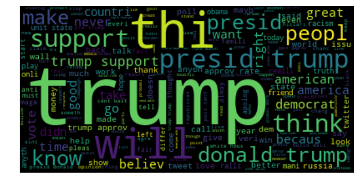

```python
# creating wordcloud of tweets classed as positive
all_pos_words = ' '.join([text for text in pos_tweets['Cleaned_Tweet_Final']])
wordcloud = WordCloud().generate(all_pos_words)
plt.figure(figsize=(10,7))
plt.imshow(wordcloud, interpolation='bilinear')
plt.axis('off')
plt.show()
```

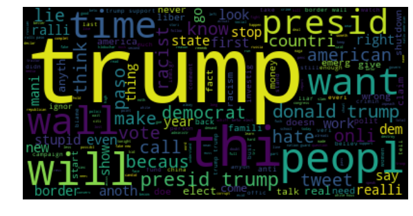

```python
# creating wordcloud of tweets classed as negative
all_neg_words = ' '.join([text for text in neg_tweets['Cleaned_Tweet_Final']])
wordcloud = WordCloud().generate(all_neg_words)
plt.figure(figsize=(10,7))
plt.imshow(wordcloud, interpolation='bilinear')
plt.axis('off')
plt.show()
```

We now need to extract features from cleaned tweets to analyse the cleaned tweets. The two techniques we will use are:

1. Bag-of-Words features: it is a method to represent text as numerical features. It involves looking at the D documents (tweets) with N unique tokens (each word) to create a D x N matrix, with each row containing the frequency of tokens in a document.
2. TF-IDF features: it is another method based on the frequency method, but it also takes into account the entire collection of tweets, not just the occurence of words. It penalises common words by assigning lower weights to more frequently occuring words.

```python
# 1. Bag-of-Words features
bow_vectorizer = CountVectorizer(max_df=0.90, min_df=2, max_features=1000, stop_words='english')
bow = bow_vectorizer.fit_transform(Labelled_Tweets['Cleaned_Tweet_Final'])
```

```python
# 2. TF-IDF features
tfidf_vectorizer = TfidfVectorizer(max_df=0.9, min_df=2, max_features=1000, stop_words='english')
tfidf = tfidf_vectorizer.fit_transform(Labelled_Tweets['Cleaned_Tweet_Final'])
```

```python
# Creating training and test data for our sentiment analysis classifier
x_train_bow, x_test_bow, y_train, y_test = train_test_split(bow, Labelled_Tweets['Sentiment'], random_state=1234, test_size=0.6)
x_train_tfidf, x_test_tfidf, y_train, y_test = train_test_split(tfidf, Labelled_Tweets['Sentiment'], random_state=1234, test_size=0.6)
```

Now that we have our training and test data, we can build a classification model to predict the sentiment of tweets. There are many different classifiers we can use, here we will use two; logistic regression, and linear support vector classification. We will apply each of these models to both the bag-of-words features and the tf-idf features to compare the performance.

```python
# Building a Logistic Regression classifier using bag-of-words features
lreg = LogisticRegression()
lreg.fit(x_train_bow,y_train.astype(str))
predictions = lreg.predict(x_test_bow)

accuracy = accuracy_score(y_test,predictions)
print(accuracy)
```

```
0.7016666666666667
```

```python
# Building a Logistic Regression classifier using tf-idf features
lreg = LogisticRegression()
lreg.fit(x_train_tfidf,y_train.astype(str))
predictions = lreg.predict(x_test_tfidf)

accuracy = accuracy_score(y_test,predictions)
print(accuracy)
```

```
0.675
```

```python
# Building a linear support vector classificaiton using bag-of words features
nb = LinearSVC()
nb.fit(x_train_bow,y_train.astype(str))
predictions = nb.predict(x_test_bow)

accuracy = accuracy_score(y_test,predictions)
print(accuracy)
```

```
0.6916666666666667
```

```python
# Building a linear support vector classificaiton using tf-idf features
nb = LinearSVC()
nb.fit(x_train_tfidf,y_train.astype(str))
predictions = nb.predict(x_test_tfidf)

accuracy = accuracy_score(y_test,predictions)
print(accuracy)
```

```
0.7183333333333334
```